# **Stacks**

Daftar Pembahasan :

- Definisi
- Operasi pada Stacks
- Contoh Implementasi Stacks
- Ekspresi Aritmatik Infix, Prefix, Postffix
- Latihan dan Percobaan Mandiri

## **Definisi Stacks**

**Stacks** merupakan salah satu struktur data dimana penambahan dan penghapusan data, hanya dapat dilakukan pada satu ujung yang **sama**, atau yang bisa dikenal dengan istilah **top**.

**Stacks (Tumpukan)** adalah sebuah tipe data abstrak linier yang berfungsi sebagai kumpulan elemen, di mana penambahan elemen baru dan penghapusan elemen yang sudah ada selalu terjadi di tempat yang sama.

Semakin data jauh berada dari posisi top, maka data tersebut diindikasikan berda di stack lebih lama dibandingkan dengan data yang berada dekat pada posisi top.

Jika terdapat data baru yang ditambahkan di stack, maka data ini pulalah yang akan dihapus ketika terdapat proses penghapusan data. Konsep ini dikenal denagan anam **LIFO-last In First Out**.

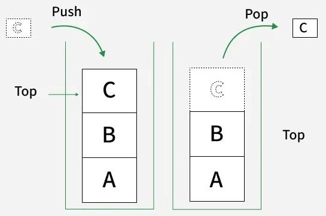

### **Prinsip LIFO (Last In First Out)**

Prinsip LIFO berarti elemen yang paling akhir ditambahkan ke dalam stack adalah elemen pertama yang akan dihapus atau diambil.

- Elemen baru selalu ditambahkan (didorong/*pushed*) ke posisi paling atas.
- Penghapusan (*pop*) juga hanya terjadi dari posisi atas.
- Aturan ini memastikan urutan yang ketat : **terakhir masuk -> pertama keluar**

### **Analogi dalam keseharian dari LIFO**

[figure not shown]

**Gambar 1. Tumpukan Koin**

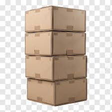

**Gambar 2. Tumpukan Kotak**

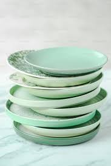

**Gambar 3. Tumpukan Piring**

Dari ketiga ilustrasi tersebut. Jika kita ingin mengambil barang yang berada di posisi paling bawah, kita wajib mengambil barang-barang yang berada di atasnya terlebih dahulu. Demikian pula jika ada penambahan barang, barang tersebut secara otomati akan berada di posisi paling atas.

## **Operasi pada Stacks**

Operasi dasar pada stacks

- **stack()**, inisialisasi stack yang kosong
- **push(data)**, penambahan data baru pada posisi top dari stack
- **pop()**, penghapusan data yang terdapat di posisi top dari stack. return value dari fungsi ini adalah data yang dihapus dari stack tersebut
- **peek()**, informasi data yang terletak pada posisi top
- **isEmpty()**, untuk memeriksa apakah stack dalam keadaan kosong
- **size()**, informasi jumlah data yang terdapat pada stack

Ilustrasi operasi **push** dan **pop**

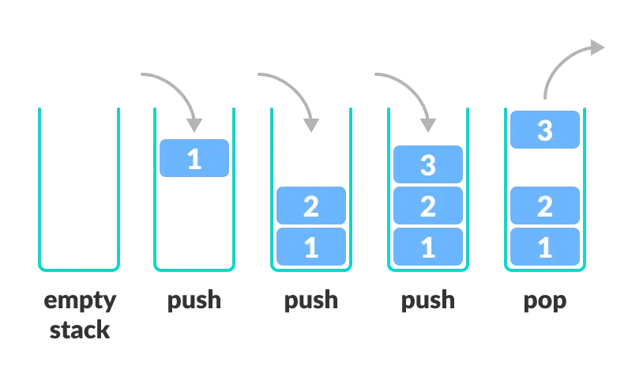